# House Prices - Avaliando o impacto das características e estimando preço de venda de imóveis

## 9.11 Assimetria

Verificando a assimetria da variável-alvo (PrecoVenda)

```r
skew(todas$PrecoVenda)
```

```
## [1] 1.877427
```

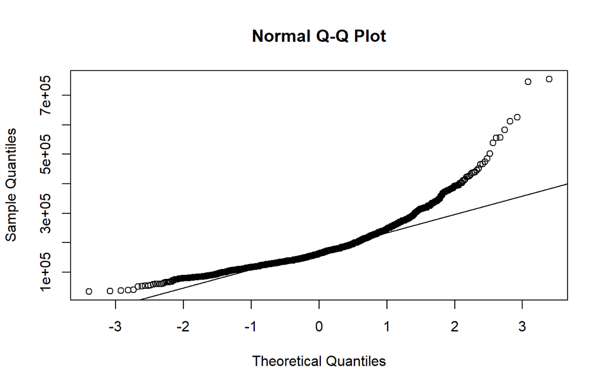

```r
qqnorm(todas$PrecoVenda)
qqline(todas$PrecoVenda)
```

Assimetria significativa e maior que zero, demonstrando cauda direita (como visto no histograma do início). Assim, será aplicado o log (não precisa +1 pois não há zeros).

```r
todas$PrecoVenda <- log(todas$PrecoVenda)

skew(todas$PrecoVenda)
```

```
## [1] 0.1213182
```

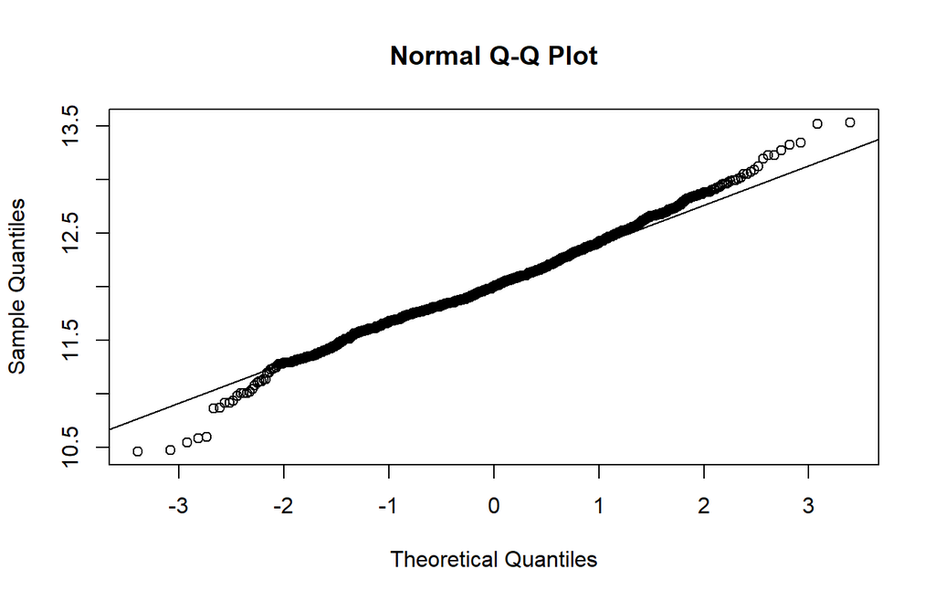

```r
qqnorm(todas$PrecoVenda)
qqline(todas$PrecoVenda)
```

Bem melhor.

## 9.12 Separando entre treinamento e teste novamente

```r
train1 <- combined[!is.na(todas$PrecoVenda),]
test1 <- combined[is.na(todas$PrecoVenda),]

dim(train1)
```

```
## [1] 1458  181
```

```r
dim(test1)
```

```
## [1] 1459  181
```

# 10 Lasso

Comparado a outros algoritmos de penalização (ridge e elatic net), o método Lasso possui a vantagem de zerar algumas variáveis pouco importantes para o modelo. Como este conjunto apresentou alguns casos de multicolinearidade e algumas correlações muito baixas, o Lasso aparenta ser uma boa opção para ligeiramente aumentar o viés em troca de uma melhor variância.

O melhor valor para lambda será testado por validação cruzada de 10 dobras para um alpha de 1.

```r
set.seed(15102020)
my_control <-trainControl(method="cv", number=10)
lassoGrid <- expand.grid(alpha = 1, lambda = seq(0.001,0.1,by = 0.0005))
lasso_mod <- train(x=train1, y=todas$PrecoVenda[!is.na(todas$PrecoVenda)], method='glmnet', trControl= my_control, tuneGrid=lassoGrid)
lasso_mod$bestTune
```

```
##   alpha lambda
## 5     1  0.003
```

RMSE: Raiz quadrada do erro médio - medida de erro residual:

```r
min(lasso_mod$results$RMSE)
```

```
## [1] 0.1125066
```

Quantas variáveis o modelo ignorou:

```r
lassoVarImp <- varImp(lasso_mod,scale=F)
lassoImportance <- lassoVarImp$importance

varsSelected <- length(which(lassoImportance$Overall!=0))
varsNotSelected <- length(which(lassoImportance$Overall==0))

cat('Lasso usou', varsSelected, 'variáveis no modelo, não selecionou', varsNotSelected, 'variáveis.')
```

```
## Lasso usou 87 variáveis no modelo, não selecionou 94 variáveis.
```

Aplicando o algoritmo no conjunto de teste:

```r
LassoPred <- predict(lasso_mod, test1)
predictions_lasso <- exp(LassoPred) # revertendo o log para ficar em valores real (dolares)
head(predictions_lasso)
```

```
##     1461     1462     1463     1464     1465     1466
## 113940.4 161820.2 179729.7 197559.1 205773.8 170131.6
```

# 11 XGBOOST